# Analisis Market dengan total penjualan (Sales) dan profit (Profit) tertinggi pada Coffee Chain Dataset

Balqis Chaessany Shadrina-M0725005

2026-04-14

## Deskripsi Insight

Insight yang diambil dalam analisis ini adalah untuk mengetahui **Market dengan total penjualan (Sales) dan profit (Profit) tertinggi pada Coffee Chain Dataset**. Analisis ini dilakukan dengan membandingkan kinerja Sales dan Profit di setiap wilayah pasar (Market).

Tujuannya adalah untuk melihat wilayah mana yang memiliki penjualan tinggi sekaligus mana yang benar-benar menghasilkan keuntungan yang lebih optimal. Dari hasil analisis juga terlihat bahwa penjualan yang tinggi tidak selalu diikuti oleh profit yang tinggi. Hal ini penting untuk menjadi bahan evaluasi, terutama terkait biaya operasional, penetapan harga, serta promosi di masing-masing wilayah.

## Connect Data SQL Ke R

```r
library(DBI)
library(odbc)
odbcListDrivers()
```

[output not shown]

[output cut: 61 more lines]

```r
DBI::dbConnect(odbc(),

               Driver = "MySQL ODBC 8.0 ANSI Driver",

               Server = "127.0.0.1",

               UID = "root",

               PWD = "Pemalang07_",

               Port = 3306)
```

```
## <OdbcConnection> root@127.0.0.1 via TCP/IP
##   Database: null
##   MySQL Version: 8.0.43
```

```r
con1 = DBI::dbConnect(odbc(),

               Driver = "MySQL ODBC 8.0 ANSI Driver",

               Server = "127.0.0.1",

               UID = "root",

               PWD = "Pemalang07_",

               Port = 3306)

con2 = DBI::dbConnect(odbc(),

                      Driver = "MySQL ODBC 8.0 ANSI Driver",

                      Server = "127.0.0.1",

                      UID = "root",

                      PWD = "Pemalang07_",

                      Port = 3306,

                      Database = "coffe_database")
```

```r
dbDisconnect(con1)
dbListTables(con2)
```

```
## [1] "facttable" "location"  "product"
```

```r
dbListFields(con2, "facttable")
```

```
##  [1] "Profit"         "Margin"         "Sales"          "COGS"
##  [5] "Total Expenses" "Marketing"      "Inventory"      "Budget Profit"
##  [9] "Budget COGS"    "Budget Margin"  "Budget Sales"   "Area Code"
## [13] "ProductId"      "Date"
```

```r
dbListFields(con2, "location")
```

```
## [1] "Area Code"   "State"       "Market"      "Market Size"
```

```r
coffee_data <- dbGetQuery(con2, "Select * from facttable")
coffee_data
```

[output not shown]

[output cut: 12732 more lines]

## Eksplorasi Data

```r
head(coffee_data)
```

```
##   Profit Margin Sales COGS Total Expenses Marketing Inventory Budget Profit
## 1     94    130   219   89             36        24       777           100
## 2     68    107   190   83             39        27       623            80
## 3    101    139   234   95             38        26       821           110
## 4     30     56   100   44             26        14       623            30
## 5     54     80   134   54             26        15       456            70
## 6     53    108   180   72             55        23       558            80
##   Budget COGS Budget Margin Budget Sales Area Code ProductId
## 1          90           130          220       719         1
## 2          80           110          190       970         2
## 3         100           140          240       970         3
## 4          30            50           80       303        13
## 5          60            90          150       303         5
## 6          80           130          210       720         6
##                  Date
## 1 2012-01-01 00:00:00
## 2 2012-01-01 00:00:00
## 3 2012-01-01 00:00:00
## 4 2012-01-01 00:00:00
## 5 2012-01-01 00:00:00
## 6 2012-01-01 00:00:00
```

```r
summary(coffee_data)
```

```
##      Profit           Margin            Sales          COGS
##  Min.   :-638.0   Min.   :-302.00   Min.   : 17   Min.   :  0.00
##  1st Qu.:  17.0   1st Qu.:  52.75   1st Qu.:100   1st Qu.: 43.00
##  Median :  40.0   Median :  76.00   Median :138   Median : 60.00
##  Mean   :  61.1   Mean   : 104.29   Mean   :193   Mean   : 84.43
##  3rd Qu.:  92.0   3rd Qu.: 132.00   3rd Qu.:230   3rd Qu.:100.00
##  Max.   : 778.0   Max.   : 613.00   Max.   :912   Max.   :364.00
##  Total Expenses     Marketing        Inventory       Budget Profit
##  Min.   : 10.00   Min.   :  0.00   Min.   :-3534.0   Min.   :-320.00
##  1st Qu.: 33.00   1st Qu.: 13.00   1st Qu.:  432.0   1st Qu.:  20.00
##  Median : 46.00   Median : 22.00   Median :  619.0   Median :  40.00
##  Mean   : 54.06   Mean   : 31.19   Mean   :  749.4   Mean   :  60.91
##  3rd Qu.: 65.00   3rd Qu.: 39.00   3rd Qu.:  910.5   3rd Qu.:  80.00
##  Max.   :190.00   Max.   :156.00   Max.   : 8252.0   Max.   : 560.00
##   Budget COGS     Budget Margin     Budget Sales      Area Code
##  Min.   :  0.00   Min.   :-210.0   Min.   :   0.0   Min.   :203.0
##  1st Qu.: 30.00   1st Qu.:  50.0   1st Qu.:  80.0   1st Qu.:417.0
##  Median : 50.00   Median :  70.0   Median : 130.0   Median :573.0
##  Mean   : 74.83   Mean   : 100.8   Mean   : 175.6   Mean   :582.3
##  3rd Qu.: 90.00   3rd Qu.: 130.0   3rd Qu.: 210.0   3rd Qu.:772.0
##  Max.   :450.00   Max.   : 690.0   Max.   :1140.0   Max.   :985.0
##    ProductId          Date
##  Min.   : 1.000   Length:4248
##  1st Qu.: 4.000   Class :character
##  Median : 6.000   Mode  :character
##  Mean   : 6.887
##  3rd Qu.:10.000
##  Max.   :13.000
```

```r
dim(coffee_data)
```

```
## [1] 4248   14
```

```r
tail(coffee_data)
```

```
##      Profit Margin Sales COGS Total Expenses Marketing Inventory Budget Profit
## 4243     68     71   128   49             25        13       845            50
## 4244     19     32    60   24             19         7       567            20
## 4245     34     80   155   65             57        24       403            30
## 4246     76     96   188   80             45        24      1079            60
## 4247     86    104   188   72             46        23       461            80
## 4248     30    145   266  105            125        95       716            50
##      Budget COGS Budget Margin Budget Sales Area Code ProductId
## 4243          40            70          110       425         9
## 4244          20            30           50       206         4
## 4245          60            80          140       509         5
## 4246          70           100          170       360         6
## 4247          80           120          200       360         2
## 4248         120           170          290       206         3
##                     Date
## 4243 2013-12-01 00:00:00
## 4244 2013-12-01 00:00:00
## 4245 2013-12-01 00:00:00
## 4246 2013-12-01 00:00:00
## 4247 2013-12-01 00:00:00
## 4248 2013-12-01 00:00:00
```

```r
names(coffee_data)
```

```
##  [1] "Profit"         "Margin"         "Sales"          "COGS"
##  [5] "Total Expenses" "Marketing"      "Inventory"      "Budget Profit"
##  [9] "Budget COGS"    "Budget Margin"  "Budget Sales"   "Area Code"
## [13] "ProductId"      "Date"
```

```r
str(coffee_data)
```

```
## 'data.frame':    4248 obs. of  14 variables:
##  $ Profit        : int  94 68 101 30 54 53 99 0 33 17 ...
##  $ Margin        : int  130 107 139 56 80 108 171 87 80 72 ...
##  $ Sales         : int  219 190 234 100 134 180 341 150 140 130 ...
##  $ COGS          : int  89 83 95 44 54 72 170 63 60 58 ...
##  $ Total Expenses: int  36 39 38 26 26 55 72 87 47 55 ...
##  $ Marketing     : int  24 27 26 14 15 23 47 57 19 22 ...
##  $ Inventory     : int  777 623 821 623 456 558 1091 435 336 338 ...
##  $ Budget Profit : int  100 80 110 30 70 80 110 20 40 20 ...
##  $ Budget COGS   : int  90 80 100 30 60 80 140 50 50 40 ...
##  $ Budget Margin : int  130 110 140 50 90 130 160 80 70 70 ...
##  $ Budget Sales  : int  220 190 240 80 150 210 300 130 120 110 ...
##  $ Area Code     : int  719 970 970 303 303 720 970 719 970 719 ...
##  $ ProductId     : int  1 2 3 13 5 6 8 9 10 11 ...
##  $ Date          : chr  "2012-01-01 00:00:00" "2012-01-01 00:00:00" "2012-01-01 00:00:00" "2012-01-01 00:00:00" ...
```

## Interpretasi :

Eksplorasi data dilakukan untuk melihat struktur awal dataset, termasuk jumlah data, tipe variabel, serta ringkasan statistik

## Agregasi Total Sales dan Profit per Market

```r
coffee_data <- dbGetQuery(con2, "
SELECT
    l.Market,
    SUM(f.Sales) AS Total_Sales,
    SUM(f.Profit) AS Total_Profit
FROM facttable AS f
JOIN location AS l
    ON f.`Area Code` = l.`Area Code`
GROUP BY l.Market
ORDER BY Total_Sales DESC
")


coffee_data
```

```
##    Market Total_Sales Total_Profit
## 1    West      272264        73996
## 2 Central      265045        93852
## 3    East      178576        59217
## 4   South      103926        32478
```

## Interpretasi :

Data kemudian diagregasi untuk menghitung total Sales dan Profit pada setiap Market. Hasil ini digunakan untuk membandingkan performa antar wilayah pasar.

## Grafik Total Penjualan per Market

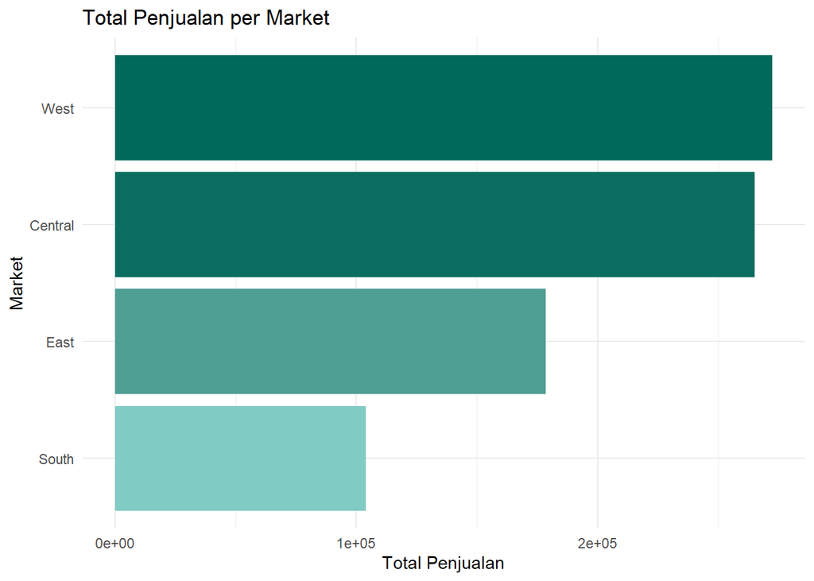

```r
ggplot(coffee_data,
       aes(x = reorder(Market, Total_Sales),
           y = Total_Sales,
           fill = Total_Sales)) +
  geom_bar(stat = "identity") +

  scale_fill_gradient(low = "#80CBC4", high = "#00695C") +
  coord_flip() +
  labs(title = "Total Penjualan per Market",
       x = "Market",
       y = "Total Penjualan") +
  theme_minimal() +
  theme(legend.position = "none")
```

## Grafik Total Profit per Market

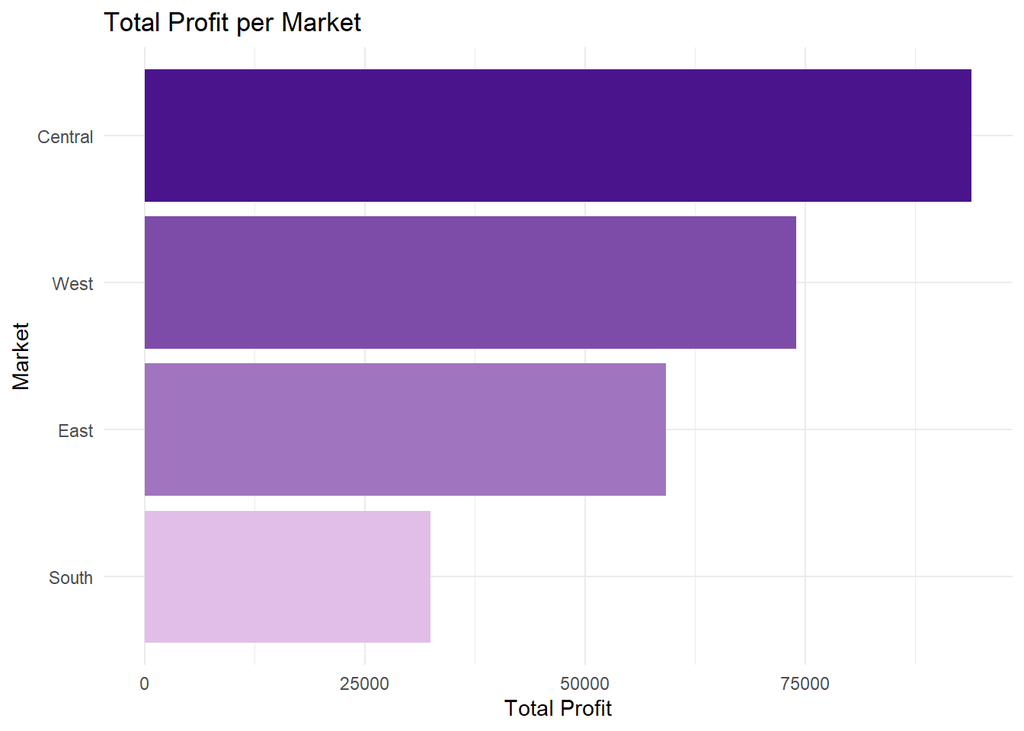

```r
library(ggplot2)
library(scales)

ggplot(coffee_data,
       aes(x = reorder(Market, Total_Profit),
           y = Total_Profit,
           fill = Total_Profit)) +
  geom_bar(stat = "identity") +
  scale_fill_gradient(low = "#E1BEE7", high = "#4A148C") +
  coord_flip() +
  labs(title = "Total Profit per Market",
       x = "Market",
       y = "Total Profit") +
  theme_minimal() +
  theme(legend.position = "none")
```

## Interpretasi: Berdasarkan kedua grafik tersebut, terlihat bahwa Market West memiliki total penjualan paling tinggi dibandingkan wilayah lain. Namun, Market Central justru memperoleh total profit yang lebih besar. Hal ini menunjukkan bahwa penjualan yang tinggi di Market West tidak selalu menghasilkan keuntungan yang lebih besar, sehingga dapat dikatakan bahwa Market Central memiliki tingkat keuntungan yang lebih baik.

## Analisis Statistika

```r
query_corr <- "
SELECT Sales, Profit
FROM facttable
"

dt_corr <- dbGetQuery(con2, query_corr)

cor_test <- cor.test(dt_corr$Sales,
                     dt_corr$Profit,
                     method = "pearson")

cor_test
```

```
##
##  Pearson's product-moment correlation
##
## data:  dt_corr$Sales and dt_corr$Profit
## t = 86.084, df = 4246, p-value < 2.2e-16
## alternative hypothesis: true correlation is not equal to 0
## 95 percent confidence interval:
##  0.7861073 0.8080289
## sample estimates:
##       cor
## 0.7973309
```

## Interpretasi

Hasil korelasi Pearson sebesar 0.797 menunjukkan hubungan positif yang kuat antara Sales dan Profit. Hal ini berarti peningkatan penjualan cenderung diikuti oleh peningkatan profit pada seluruh market.

Selain itu, nilai p-value yang sangat kecil (< 0.05) menunjukkan bahwa hubungan tersebut signifikan secara statistik, sehingga hubungan ini tidak terjadi secara kebetulan melainkan benar-benar saling berkaitan satu sama lain.

## Kesimpulan

Berdasarkan hasil analisis Coffee Chain Dataset, terdapat perbedaan kinerja antar market berdasarkan total penjualan dan profit, di mana Market Central dan West menunjukkan performa yang lebih tinggi dibandingkan market lainnya. Market West memiliki penjualan tertinggi, namun Market Central lebih efisien karena mampu menghasilkan profit lebih besar.

Selain itu, terdapat hubungan positif yang cukup kuat dan signifikan antara Sales dan Profit, yang berarti semakin tinggi penjualan maka profit juga cenderung meningkat.